# Exploring Dynamic Community Occupancy Models in Cambodia Protected Areas

Authors

Affiliations

Nan NOURN

Michigan State University

Jackson FRECHETTE

Conservation International

Dan KRAMER

Michigan State University

Published

August 22, 2025

Abstract

We explore dynamic community models (DCM) to explore occupancy analyses related to predator and prey communities in Cambodia. Specifically, we leverage wildlife detection/non-detection data occurrence collected from camerea trap arrays across multiple protected areas in Cambodia.

Keywords

Cambodia, Ecology, Occupancy model, Camera trap

```r
library(tidyverse)
library(tidybayes)
library(abind)
library(jagsUI)
library(sf)
library(terra)
library(tmap)
library(gt)
library(readxl)
library(here)
theme_set(theme_light(base_size = 11))
options(scipen = 10^4)
set.seed(855)
here()
```

```
[1] "/Users/nan/Library/CloudStorage/OneDrive-MichiganStateUniversity/Web/pa-msom-predprey"
```

```r
# data file directory
data <- here("data")
models <- here("models")
```

# Introduction

# Study Site

## CCMNP

```r
# check excel worksheets
excel_sheets(here(data, "cameratrap_data_nan_2024.xlsx"))
```

```
[1] "images" "camera" "taxa"   "notes"
```

```r
# read in EXCEL worksheets
detections <- read_xlsx(here(data, "cameratrap_data_nan_2024.xlsx"), sheet = "images")
taxa <- read_xlsx(here(data, "cameratrap_data_nan_2024.xlsx"), sheet = "taxa")
deployments <- read_xlsx(here(data, "cameratrap_data_nan_2024.xlsx"), sheet = "camera")
cambo.PA <- st_read(here(data, "npa_en.gpkg"))
boundary <- cambo.PA |> filter(name=="Central Cardamom Mountains National Park")

# set up camera trap deployment maps
deployments.sf <- deployments |> st_as_sf(coords = c("utm_x","utm_y"), crs = 32648)
st_crs(deployments.sf)
```

[output not shown]

```r
# arrange camera id name columns
deployments.sf <- deployments.sf |> relocate(camera_id_pool)

# create buffer
buffer.1km <- st_buffer(deployments.sf, dist = 565) # radius 500m
(sqrt(st_area(buffer.1km)))                   # check buffer size (1 km^2)
```

```
Units: [m]
  [1] 1001.208 1001.208 1001.208 1001.208 1001.208 1001.208 1001.208 1001.208
  [9] 1001.208 1001.208 1001.208 1001.208 1001.208 1001.208 1001.208 1001.208
 [17] 1001.208 1001.208 1001.208 1001.208 1001.208 1001.208 1001.208 1001.208
 [25] 1001.208 1001.208 1001.208 1001.208 1001.208 1001.208 1001.208 1001.208
 [33] 1001.208 1001.208 1001.208 1001.208 1001.208 1001.208 1001.208 1001.208
 [41] 1001.208 1001.208 1001.208 1001.208 1001.208 1001.208 1001.208 1001.208
 [49] 1001.208 1001.208 1001.208 1001.208 1001.208 1001.208 1001.208 1001.208
 [57] 1001.208 1001.208 1001.208 1001.208 1001.208 1001.208 1001.208 1001.208
 [65] 1001.208 1001.208 1001.208 1001.208 1001.208 1001.208 1001.208 1001.208
 [73] 1001.208 1001.208 1001.208 1001.208 1001.208 1001.208 1001.208 1001.208
 [81] 1001.208 1001.208 1001.208 1001.208 1001.208 1001.208 1001.208 1001.208
 [89] 1001.208 1001.208 1001.208 1001.208 1001.208 1001.208 1001.208 1001.208
 [97] 1001.208 1001.208 1001.208 1001.208 1001.208 1001.208 1001.208 1001.208
[105] 1001.208 1001.208 1001.208 1001.208 1001.208 1001.208 1001.208 1001.208
[113] 1001.208 1001.208 1001.208 1001.208 1001.208 1001.208 1001.208 1001.208
[121] 1001.208 1001.208 1001.208 1001.208 1001.208 1001.208 1001.208 1001.208
[129] 1001.208 1001.208 1001.208 1001.208 1001.208 1001.208 1001.208 1001.208
[137] 1001.208 1001.208 1001.208 1001.208 1001.208 1001.208 1001.208
```

```r
# interactive tmap mode
tmap_mode("view")
# set tmap interactive baselayers
tmap_options(basemap.server = c(Canvas = "Esri.WorldGrayCanvas",
                          Imagery = "Esri.WorldImagery",
                          Topo = "Esri.WorldTopoMap"))

# create map
tm_shape(deployments.sf) +
  tm_dots(fill = "season",
          fill.scale = tm_scale(style = "categorical",
                                values = "viridis"),
          fill_alpha = 0.75,
          size = 0.6) +
tm_shape(boundary) +
  tm_borders(col = "yellow") +
tm_shape(buffer.1km) +
  tm_borders(col = "red", lty = 2)
```

[interactive chart not shown]

# Data

## Camera Trap

From the camera trap arrays within each protected area, we used the R package `camtrapR` to produce species detection matrices for multiple species. The matrices (M x J) and arrays (M x J x T) (M x J x T x Sp) with dimensions (site x survey period x primary season) for dynamic occupancy models for single species while increased by another dimension for our dynamic community models (site x survey period x primary season x species).

```r
# load multi-season detection matrices

# wild pig
wild.pig <- read_csv(here(data, "detection_matrix_wildpig_multi.csv"))
sites <- wild.pig[,1] |> rename(sites=1) # set up sites
wild.pig <- wild.pig[,-1] |> as.matrix()
wild.pig <- unname(wild.pig)
# arrange separate matrices for dry and wet season
# periods 1:5 -> dry; periods 6-10 -> wet
wild.pig.dry <- wild.pig[, 1:5]
wild.pig.wet <- wild.pig[, 6:10]

# muntjac
muntjac <- read_csv(here(data, "detection_matrix_muntjac_multi.csv"))
muntjac <- muntjac[,-1] |> as.matrix()
muntjac <- unname(muntjac)
# arrange separate matrices for dry and wet season
# periods 1:5 -> dry; periods 6-10 -> wet
muntjac.dry <- muntjac[, 1:5]
muntjac.wet <- muntjac[, 6:10]

# chevrotain
chevrotain <- read_csv(here(data, "detection_matrix_chevrotain_multi.csv"))
chevrotain <- chevrotain[,-1] |> as.matrix()
chevrotain <- unname(chevrotain)
# arrange separate matrices for dry and wet season
# periods 1:5 -> dry; periods 6-10 -> wet
chevrotain.dry <- chevrotain[, 1:5]
chevrotain.wet <- chevrotain[, 6:10]
```

## Covariates

### Ecological

### Observation

# Methods

## Statistical Analyses

## Models

### Static Occupancy Model (single species, multiple species, fixed season)

We look at single-season static occupancy models one species at a time, and one season at a time due to the closure assumption of both seperate dry and wet seasons. So this is really 6 fitted seperate occupancy models.

JAGS syntax:

```r
model {
  # Priors
  psi ~ dunif(0, 1)
  p ~ dunif(0, 1)
  # Likelihood
  for (i in 1:M) {    # Loop over sites
    z[i] ~ dbern(psi)         # State model
    for (j in 1:J) { # Loop over replicate surveys
      y[i,j] ~ dbern(z[i]*p)  # Observation model (only JAGS !)
      # y[i,j] ~ dbern(mu[i])  # For WinBUGS define 'straw man'
    }
    # mu[i] <- z[i]*p          # Only WinBUGS
  }
}
```

```r
# set up model dimensions
# should be similar across different seasons and species
M <- nrow(wild.pig.dry)                   # Number of sites
#M <- nrow(wild.pig.wet)
#J <- ncol(wild.pig.dry)
J <- ncol(wild.pig.wet)                   # Number of presence/absence measurements

# bundle data
wild.pig.dry.data <- list(y = wild.pig.dry, M = nrow(wild.pig.dry),
                          J = ncol(wild.pig.dry))
wild.pig.wet.data <- list(y = wild.pig.wet, M = nrow(wild.pig.wet),
                          J = ncol(wild.pig.wet))
muntjac.dry.data <- list(y = muntjac.dry, M = nrow(muntjac.dry),
                          J = ncol(muntjac.dry))
muntjac.wet.data <- list(y = muntjac.wet, M = nrow(muntjac.wet),
                          J = ncol(muntjac.wet))
chevrotain.dry.data <- list(y = chevrotain.dry, M = nrow(chevrotain.dry),
                          J = ncol(chevrotain.dry))
chevrotain.wet.data <- list(y = chevrotain.wet, M = nrow(chevrotain.wet),
                          J = ncol(chevrotain.wet))


# initial values
wild.pig.dry.zst <- rep(1, wild.pig.dry.data$M)
wild.pig.dry.inits <- function(){list(z = wild.pig.dry.zst)}
wild.pig.wet.zst <- rep(1, wild.pig.wet.data$M)
wild.pig.wet.inits <- function(){list(z = wild.pig.wet.zst)}

muntjac.dry.zst <- rep(1, muntjac.dry.data$M)
muntjac.dry.inits <- function(){list(z = muntjac.dry.zst)}
muntjac.wet.zst <- rep(1, muntjac.wet.data$M)
muntjac.wet.inits <- function(){list(z = muntjac.wet.zst)}

chevrotain.dry.zst <- rep(1, chevrotain.dry.data$M)
chevrotain.dry.inits <- function(){list(z = chevrotain.dry.zst)}
chevrotain.wet.zst <- rep(1, chevrotain.wet.data$M)
chevrotain.wet.inits <- function(){list(z = chevrotain.wet.zst)}

# Parameters monitored
params <- c("psi", "p")

# MCMC settings
ni <- 5000   ;   nt <- 1   ;   nb <- 1000   ;   nc <- 3

# fit the seperate species and season models
wild.pig.dry.fm1 <- jags(wild.pig.dry.data, wild.pig.dry.inits, params,
                     here(models, "ssom_naive.txt"),
                     n.chains = nc, n.thin = nt, n.iter = ni, n.burnin = nb)
```

```
Processing function input.......

Done.



Adaptive phase.....
Adaptive phase complete


 Burn-in phase, 1000 iterations x 3 chains


Sampling from joint posterior, 4000 iterations x 3 chains


Calculating statistics.......

Done.
```

```r
wild.pig.wet.fm1 <- jags(wild.pig.wet.data, wild.pig.wet.inits, params,
                     here(models, "ssom_naive.txt"),
                     n.chains = nc, n.thin = nt, n.iter = ni, n.burnin = nb)
```

```
Processing function input.......

Done.



Adaptive phase.....
Adaptive phase complete


 Burn-in phase, 1000 iterations x 3 chains


Sampling from joint posterior, 4000 iterations x 3 chains


Calculating statistics.......

Done.
```

```r
muntjac.dry.fm1 <- jags(muntjac.dry.data, muntjac.dry.inits, params,
                     here(models, "ssom_naive.txt"),
                     n.chains = nc, n.thin = nt, n.iter = ni, n.burnin = nb)
```

```
Processing function input.......

Done.



Adaptive phase.....
Adaptive phase complete


 Burn-in phase, 1000 iterations x 3 chains


Sampling from joint posterior, 4000 iterations x 3 chains


Calculating statistics.......

Done.
```

```r
muntjac.wet.fm1 <- jags(muntjac.wet.data, muntjac.wet.inits, params,
                     here(models, "ssom_naive.txt"),
                     n.chains = nc, n.thin = nt, n.iter = ni, n.burnin = nb)
```

```
Processing function input.......

Done.



Adaptive phase.....
Adaptive phase complete


 Burn-in phase, 1000 iterations x 3 chains


Sampling from joint posterior, 4000 iterations x 3 chains


Calculating statistics.......

Done.
```

```r
chevrotain.dry.fm1 <- jags(chevrotain.dry.data, chevrotain.dry.inits, params,
                     here(models, "ssom_naive.txt"),
                     n.chains = nc, n.thin = nt, n.iter = ni, n.burnin = nb)
```

```
Processing function input.......

Done.



Adaptive phase.....
Adaptive phase complete


 Burn-in phase, 1000 iterations x 3 chains


Sampling from joint posterior, 4000 iterations x 3 chains


Calculating statistics.......

Done.
```

```r
chevrotain.wet.fm1 <- jags(chevrotain.wet.data, chevrotain.wet.inits, params,
                     here(models, "ssom_naive.txt"),
                     n.chains = nc, n.thin = nt, n.iter = ni, n.burnin = nb)
```

```
Processing function input.......

Done.



Adaptive phase.....
Adaptive phase complete


 Burn-in phase, 1000 iterations x 3 chains


Sampling from joint posterior, 4000 iterations x 3 chains


Calculating statistics.......

Done.
```

```r
# combine all fitted models into list
ssom.fm1 <- list(pig.dry = wild.pig.dry.fm1, pig.wet = wild.pig.wet.fm1,
                 muntjac.dry = muntjac.dry.fm1, muntjac.wet = muntjac.wet.fm1,
                 chevrotain.dry = chevrotain.dry.fm1,
                 chevrotain.wet = chevrotain.wet.fm1)

# check summary
ssom.fm1 |> lmap(print, dig = 3)
```

```
$pig.dry
JAGS output for model '/Users/nan/Library/CloudStorage/OneDrive-MichiganStateUniversity/Web/pa-msom-predprey/models/ssom_naive.txt', generated by jagsUI.
Estimates based on 3 chains of 5000 iterations,
adaptation = 100 iterations (sufficient),
burn-in = 1000 iterations and thin rate = 1,
yielding 12000 total samples from the joint posterior.
MCMC ran for 0.01 minutes at time 2025-08-22 19:57:21.897587.

            mean     sd    2.5%     50%   97.5% overlap0 f  Rhat n.eff
psi        0.623  0.073   0.482   0.623   0.768    FALSE 1 1.001  2064
p          0.534  0.049   0.436   0.534   0.629    FALSE 1 1.001  1376
deviance 208.071 12.247 188.293 206.626 236.352    FALSE 1 1.002   990

Successful convergence based on Rhat values (all < 1.1).
Rhat is the potential scale reduction factor (at convergence, Rhat=1).
For each parameter, n.eff is a crude measure of effective sample size.

overlap0 checks if 0 falls in the parameter's 95% credible interval.
f is the proportion of the posterior with the same sign as the mean;
i.e., our confidence that the parameter is positive or negative.

DIC info: (pD = var(deviance)/2)
pD = 74.9 and DIC = 282.924
DIC is an estimate of expected predictive error (lower is better).

$pig.wet
JAGS output for model '/Users/nan/Library/CloudStorage/OneDrive-MichiganStateUniversity/Web/pa-msom-predprey/models/ssom_naive.txt', generated by jagsUI.
Estimates based on 3 chains of 5000 iterations,
adaptation = 100 iterations (sufficient),
burn-in = 1000 iterations and thin rate = 1,
yielding 12000 total samples from the joint posterior.
MCMC ran for 0.012 minutes at time 2025-08-22 19:57:22.531152.

            mean    sd    2.5%     50%   97.5% overlap0 f  Rhat n.eff
psi        0.777 0.054   0.663   0.779   0.874    FALSE 1 1.000  4126
p          0.615 0.036   0.544   0.616   0.683    FALSE 1 1.000 12000
deviance 263.003 7.478 253.045 261.144 281.233    FALSE 1 1.001  3798

Successful convergence based on Rhat values (all < 1.1).
Rhat is the potential scale reduction factor (at convergence, Rhat=1).
```

[output cut: 94 more lines]

```
psi        0.436 0.072   0.304   0.432   0.583    FALSE 1    1 12000
p          0.431 0.056   0.322   0.431   0.538    FALSE 1    1 12000
deviance 153.823 9.535 139.812 152.292 176.013    FALSE 1    1 12000

Successful convergence based on Rhat values (all < 1.1).
Rhat is the potential scale reduction factor (at convergence, Rhat=1).
For each parameter, n.eff is a crude measure of effective sample size.

overlap0 checks if 0 falls in the parameter's 95% credible interval.
f is the proportion of the posterior with the same sign as the mean;
i.e., our confidence that the parameter is positive or negative.

DIC info: (pD = var(deviance)/2)
pD = 45.5 and DIC = 199.283
DIC is an estimate of expected predictive error (lower is better).
```

[output not shown]

[output not shown]

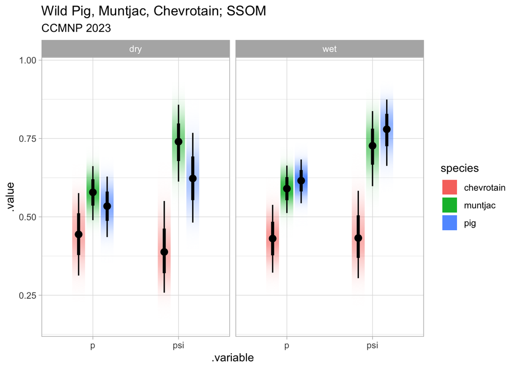

```r
# list outputs to plot all models and parameters
ssom.fm1 |>
  map_dfr(gather_draws, psi, p, .id = "model") |>
   separate_wider_delim(cols = model,
                        delim = ".",
                        names = c("species", "season")) |>
  ggplot(aes(x = .variable, y = .value, fill = species)) +
  stat_gradientinterval(position = "dodge", width = 0.5) +
  labs(title = "Wild Pig, Muntjac, Chevrotain; SSOM",
       subtitle = "CCMNP 2023") +
  facet_wrap(~ season)
```

### Dynamic Occupancy Models (single species)

Now we look at single-species dynamic occupancy models, observing changes from dry season to wet season for our 3 ungulate species.

This is really 3 seperate fitted dynamic occupancy models.

JAGS syntax:

```r
model {

  # Priors
  psi1 ~ dunif(0, 1)
  phi ~ dunif(0, 1)
  gamma ~ dunif(0, 1)
  p ~ dunif(0, 1)

  # Likelihood
  # Ecological submodel: Define state conditional on parameters
  for (i in 1:nsites){ # Loop over nsites sites
    # Initial conditions of system
    z[i,1] ~ dbern(psi1) # Presence/absence at start of study
    # State transitions
    for (t in 2:nyears){ # Loop over nyears years
      z[i,t] ~ dbern(z[i,t-1] * phi + (1-z[i,t-1]) * gamma)
    }
  }

  # Observation model
  for (i in 1:nsites){
    for (j in 1:nsurveys){
      for (t in 1:nyears){
        y[i,j,t] ~ dbern(z[i,t] * p)
      }
    }
  }

  # Derived parameters
  eps <- 1 - phi # Extinction probability
  psi[1] <- psi1 # Population occupancy
  for (t in 2:nyears){
    psi[t] <- psi[t-1] * phi + (1-psi[t-1]) * gamma
  }
}
```

```r
# turn seasonal matrices into arrays with dimensions (site x survey x seasons)
wild.pig2 <- abind(wild.pig.dry, wild.pig.wet, along = 2.5)
dim(wild.pig2)
```

```
[1] 69  5  2
```

```r
muntjac2 <- abind(muntjac.dry, muntjac.wet, along = 2.5)
dim(muntjac2)
```

```
[1] 69  5  2
```

```r
chevrotain2 <- abind(chevrotain.dry, chevrotain.wet, along = 2.5)
dim(chevrotain2)
```

```
[1] 69  5  2
```

```r
# JAGS
# Bundle and summarize data
wild.pig.data <- list(y = wild.pig2,
                     nsites = dim(wild.pig2)[1],
                     nsurveys = dim(wild.pig2)[2],
                     nyears = dim(wild.pig2)[3])
muntjac.data <- list(y = muntjac2,
                     nsites = dim(muntjac2)[1],
                     nsurveys = dim(muntjac2)[2],
                     nyears = dim(muntjac2)[3])
chevrotain.data <- list(y = chevrotain2,
                     nsites = dim(chevrotain2)[1],
                     nsurveys = dim(chevrotain2)[2],
                     nyears = dim(chevrotain2)[3])

# Initial values
wild.pig.zobs <- apply(wild.pig2, c(1,3), function(x) max(x, na.rm = TRUE))
wild.pig.zobs[wild.pig.zobs == '-Inf'] <- NA     # site/years without visits
wild.pig.zst <- wild.pig.zobs     # Obs. occurrence as inits for z
wild.pig.inits <- function(){ list(z = wild.pig.zst)}

muntjac.zobs <- apply(muntjac2, c(1,3), function(x) max(x, na.rm = TRUE))
muntjac.zobs[muntjac.zobs == '-Inf'] <- NA     # site/years without visits
muntjac.zst <- muntjac.zobs     # Obs. occurrence as inits for z
muntjac.inits <- function(){ list(z = muntjac.zst)}

chevrotain.zobs <- apply(chevrotain2, c(1,3), function(x) max(x, na.rm = TRUE))
chevrotain.zobs[chevrotain.zobs == '-Inf'] <- NA     # site/years without visits
chevrotain.zst <- chevrotain.zobs     # Obs. occurrence as inits for z
chevrotain.inits <- function(){ list(z = chevrotain.zst)}

# Parameters monitored
params <- c("psi1", "phi", "eps", "gamma", "p", "psi", "z") # Could add 'z'

# MCMC settings
na <- 1000 ; ni <- 20000 ; nt <- 10 ; nb <- 10000 ; nc <- 3

# Call JAGS (ART 3 min), check convergence and summarize posteriors
wild.pig.fm2 <- jags(wild.pig.data, wild.pig.inits, params,
                     here(models,"dynocc_naive.txt"),
                     n.adapt = na, n.chains = nc, n.thin = nt, n.iter = ni, n.burnin = nb,
                     parallel = TRUE)
```

```
Processing function input.......

Done.

Beginning parallel processing using 3 cores. Console output will be suppressed.

Parallel processing completed.

Calculating statistics.......

Done.
```

```r
muntjac.fm2 <- jags(muntjac.data, muntjac.inits, params, here(models,"dynocc_naive.txt"),
                    n.adapt = na, n.chains = nc, n.thin = nt, n.iter = ni, n.burnin = nb,
                    parallel = TRUE)
```

```
Processing function input.......

Done.

Beginning parallel processing using 3 cores. Console output will be suppressed.

Parallel processing completed.

Calculating statistics.......

Done.
```

```r
chevrotain.fm2 <- jags(chevrotain.data, chevrotain.inits, params, here(models,"dynocc_naive.txt"),
                    n.adapt = na, n.chains = nc, n.thin = nt, n.iter = ni, n.burnin = nb,
                    parallel = TRUE)
```

```
Processing function input.......

Done.

Beginning parallel processing using 3 cores. Console output will be suppressed.

Parallel processing completed.

Calculating statistics.......

Done.
```

```r
# combine all fitted model outputs into list
dynocc.fm2 <- list(pig = wild.pig.fm2, muntjac = muntjac.fm2,
                    chevrotain = chevrotain.fm2)

# check summary
dynocc.fm2 |> lmap(print, dig = 3)
```

```
$pig
JAGS output for model '/Users/nan/Library/CloudStorage/OneDrive-MichiganStateUniversity/Web/pa-msom-predprey/models/dynocc_naive.txt', generated by jagsUI.
Estimates based on 3 chains of 20000 iterations,
adaptation = 1000 iterations (sufficient),
burn-in = 10000 iterations and thin rate = 10,
yielding 3000 total samples from the joint posterior.
MCMC ran in parallel for 0.048 minutes at time 2025-08-22 19:57:27.617103.

            mean     sd    2.5%     50%   97.5% overlap0 f  Rhat n.eff
psi1       0.606  0.067   0.469   0.607   0.733    FALSE 1 1.000  3000
phi        0.868  0.057   0.742   0.876   0.958    FALSE 1 1.000  3000
eps        0.132  0.057   0.042   0.124   0.258    FALSE 1 1.000  3000
gamma      0.604  0.110   0.376   0.609   0.799    FALSE 1 1.000  3000
p          0.584  0.029   0.527   0.585   0.639    FALSE 1 1.001  1372
psi[1]     0.606  0.067   0.469   0.607   0.733    FALSE 1 1.000  3000
psi[2]     0.765  0.053   0.653   0.766   0.863    FALSE 1 1.000  3000
z[1,1]     0.152  0.359   0.000   0.000   1.000     TRUE 1 1.000  3000
z[2,1]     1.000  0.000   1.000   1.000   1.000    FALSE 1    NA     1
z[3,1]     1.000  0.000   1.000   1.000   1.000    FALSE 1    NA     1
z[4,1]     1.000  0.000   1.000   1.000   1.000    FALSE 1    NA     1
z[5,1]     0.083  0.275   0.000   0.000   1.000     TRUE 1 1.003  1658
z[6,1]     0.143  0.350   0.000   0.000   1.000     TRUE 1 1.001  2502
z[7,1]     1.000  0.000   1.000   1.000   1.000    FALSE 1    NA     1
z[8,1]     0.291  0.454   0.000   0.000   1.000     TRUE 1 1.000  3000
z[9,1]     0.352  0.478   0.000   0.000   1.000     TRUE 1 1.000  3000
z[10,1]    0.691  0.462   0.000   1.000   1.000     TRUE 1 1.000  3000
z[11,1]    0.675  0.468   0.000   1.000   1.000     TRUE 1 1.001  1188
z[12,1]    1.000  0.000   1.000   1.000   1.000    FALSE 1    NA     1
z[13,1]    1.000  0.000   1.000   1.000   1.000    FALSE 1    NA     1
z[14,1]    1.000  0.000   1.000   1.000   1.000    FALSE 1    NA     1
z[15,1]    0.143  0.350   0.000   0.000   1.000     TRUE 1 1.002  1797
z[16,1]    0.086  0.281   0.000   0.000   1.000     TRUE 1 1.000  3000
z[17,1]    0.042  0.201   0.000   0.000   1.000     TRUE 1 1.000  3000
z[18,1]    1.000  0.000   1.000   1.000   1.000    FALSE 1    NA     1
z[19,1]    0.283  0.451   0.000   0.000   1.000     TRUE 1 1.001  1874
z[20,1]    1.000  0.000   1.000   1.000   1.000    FALSE 1    NA     1
z[21,1]    1.000  0.000   1.000   1.000   1.000    FALSE 1    NA     1
z[22,1]    1.000  0.000   1.000   1.000   1.000    FALSE 1    NA     1
z[23,1]    1.000  0.000   1.000   1.000   1.000    FALSE 1    NA     1
z[24,1]    1.000  0.000   1.000   1.000   1.000    FALSE 1    NA     1
```

[output cut: 451 more lines]

```
z[69,2]    0.264  0.441   0.000   0.000   1.000     TRUE 1 1.000  3000
deviance 269.321 12.016 248.156 268.591 295.551    FALSE 1 1.000  3000

**WARNING** Some Rhat values could not be calculated.
Successful convergence based on Rhat values (all < 1.1).
Rhat is the potential scale reduction factor (at convergence, Rhat=1).
For each parameter, n.eff is a crude measure of effective sample size.

overlap0 checks if 0 falls in the parameter's 95% credible interval.
f is the proportion of the posterior with the same sign as the mean;
i.e., our confidence that the parameter is positive or negative.

DIC info: (pD = var(deviance)/2)
pD = 72.2 and DIC = 341.555
DIC is an estimate of expected predictive error (lower is better).
```

[output not shown]

[output not shown]

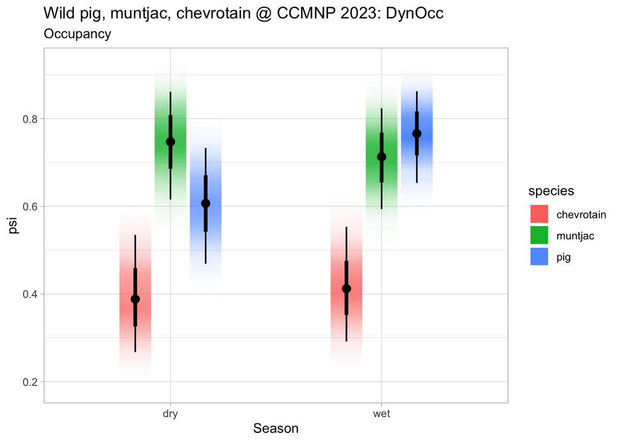

```r
# set up summary tables for plots
# psi
dynocc.fm2 |>
  map_dfr(gather_draws, psi[i], .id = "species") |>
  mutate(season = case_when(i == 1 ~ "dry",
                            i == 2 ~ "wet" )) |>
  ggplot(aes(x = season, y = .value, fill = species)) +
  stat_gradientinterval(position = "dodge", width = 0.5) +
  labs(title = "Wild pig, muntjac, chevrotain @ CCMNP 2023: DynOcc",
       subtitle = "Occupancy",
       x = "Season",
       y = "psi")
```

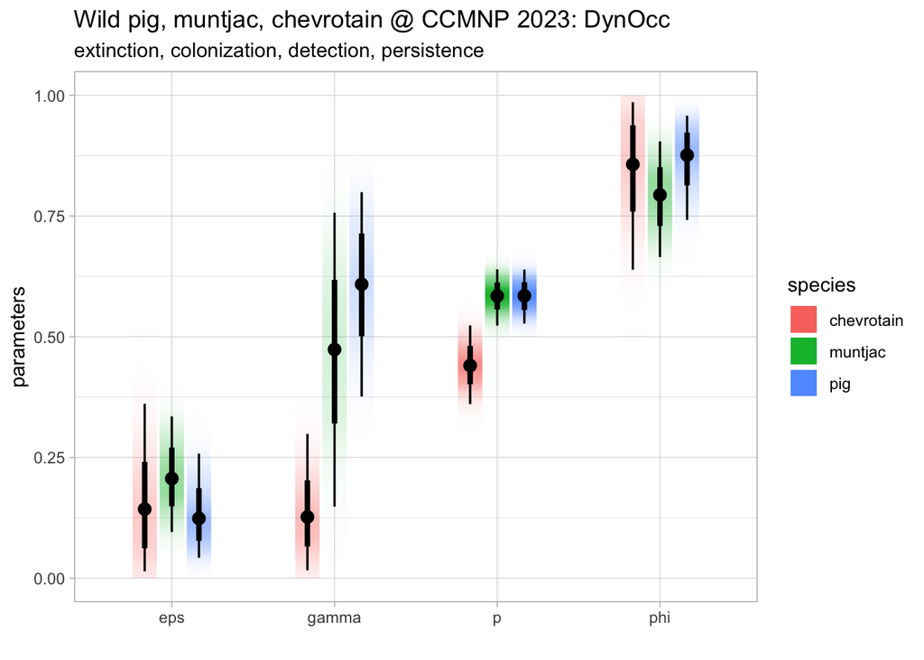

```r
# all other parameters
dynocc.fm2 |>
  map_dfr(gather_draws, phi, eps, gamma, p, .id = "species") |>
  ggplot(aes(x = .variable, y = .value, fill = species)) +
  stat_gradientinterval(position = "dodge", width = 0.5) +
  labs(title = "Wild pig, muntjac, chevrotain @ CCMNP 2023: DynOcc",
       subtitle = "extinction, colonization, detection, persistence",
       x = "",
       y = "parameters")
```

```r
# phi : persistence probability
# gamma: colonization probability
# epsilon: extinction probability
```

### Dynamic Community Model (multiple species)

Next we combine arrays and add the species $k$ dimension and attempt to fit a Dynamic Community Model.

1. Initial state for species $k$:

$$z_i,1,k \sim Bernoulli(\psi_k)$$

2. State dynamics for species $k$:

$$z_{i, t+1, k} \mid z_{i,t,k} \sim Bernoulli(z_{i,t,k} \phi_k + (1-z_{i,t,k})\gamma_k)$$

3. Observation process for species $k$:

$$y_{i,j,t,k} \mid z_{i,t,k} \sim Bernoulli(z_{i,t,k}p_{k})$$